# Part I - fordgobike-tripdata

## Introduction

> This data set includes information about individual rides made in a bike-sharing system covering the greater San Francisco Bay area.

## Preliminary Wrangling

```python
!pip install seaborn==0.11.0
```

```python
# import all packages and set plots to be embedded inline
import numpy as np
import pandas as pd
import matplotlib.pyplot as plt
import seaborn as sb

%matplotlib inline
```

Dataset 1 - df_allyear

```python
df1=pd.read_csv('data/201901-fordgobike-tripdata.csv',low_memory=False)
df2=pd.read_csv('data/201902-fordgobike-tripdata.csv',low_memory=False)
df3=pd.read_csv('data/201903-fordgobike-tripdata.csv',low_memory=False)
df4=pd.read_csv('data/201904-fordgobike-tripdata.csv',low_memory=False)
df5=pd.read_csv('data/201905-baywheels-tripdata.csv',low_memory=False)
df6=pd.read_csv('data/201906-baywheels-tripdata.csv',low_memory=False)
df7=pd.read_csv('data/201907-baywheels-tripdata.csv',low_memory=False)
df8=pd.read_csv('data/201908-baywheels-tripdata.csv',low_memory=False)
df9=pd.read_csv('data/201909-baywheels-tripdata.csv',low_memory=False)
df10=pd.read_csv('data/201910-baywheels-tripdata.csv',low_memory=False)
df11=pd.read_csv('data/201911-baywheels-tripdata.csv',low_memory=False)
df12=pd.read_csv('data/201912-baywheels-tripdata.csv',low_memory=False)
```

```python
#Create a dataframe with agregation of the datasets collected for all months of year 2019
# --> it does not include all the original (given) dataset variables, like member_birth_year,
# member_gender, bike_share_for_all_trip

frames = [df1, df2, df3, df4, df5, df6, df7, df8, df9, df10, df11, df12]

df_allyear = pd.concat(frames, join='inner')


df_allyear.info(verbose=True, null_counts=True)
```

```
<class 'pandas.core.frame.DataFrame'>
Int64Index: 2506983 entries, 0 to 150101
Data columns (total 13 columns):
duration_sec               2506983 non-null int64
start_time                 2506983 non-null object
end_time                   2506983 non-null object
start_station_id           2426249 non-null float64
start_station_name         2426850 non-null object
start_station_latitude     2506983 non-null float64
start_station_longitude    2506983 non-null float64
end_station_id             2424081 non-null float64
end_station_name           2424633 non-null object
end_station_latitude       2506983 non-null float64
end_station_longitude      2506983 non-null float64
bike_id                    2506983 non-null int64
user_type                  2506983 non-null object
dtypes: float64(6), int64(2), object(5)
memory usage: 267.8+ MB
```

```python
#Drop NA values in the dataset
df_allyear=df_allyear.dropna(axis = 0, how ='any');
```

```python
#Change the datatypes
df_allyear['start_time'] = pd.to_datetime(df_allyear['start_time'])
df_allyear['end_time'] = pd.to_datetime(df_allyear['end_time'])

# using dictionary to convert specific columns
convert_dict = {'start_station_id': str,
                'start_station_name': str,
                'end_station_id': str,
                'end_station_name': str,
                'bike_id': str,
                'user_type': 'category',
                }

df_allyear = df_allyear.astype(convert_dict)
print(df_allyear.dtypes)
```

```
duration_sec                        int64
start_time                 datetime64[ns]
end_time                   datetime64[ns]
start_station_id                   object
start_station_name                 object
start_station_latitude            float64
start_station_longitude           float64
end_station_id                     object
end_station_name                   object
end_station_latitude              float64
end_station_longitude             float64
bike_id                            object
user_type                        category
dtype: object
```

```python
#Create new column with the name of the week and weenkend day
df_allyear['day']=df_allyear['start_time'].dt.strftime('%A').astype('category')
df_allyear.sample(1)
```

|  | duration_sec | start_time | end_time | start_station_id | start_station_name | start_station_latitude | start_station_longitude | end_station_id | end_station_name | end_station_latitude | end_station_longitude | bike_id | user_type | day |
| --- | --- | --- | --- | --- | --- | --- | --- | --- | --- | --- | --- | --- | --- | --- |
| 140215 | 1171 | 2019-09-12 08:31:20.683 | 2019-09-12 08:50:52.292 | 371.0 | Lombard St at Columbus Ave | 37.802746 | -122.413579 | 81.0 | Berry St at 4th St | 37.77588 | -122.39317 | 11825 | Subscriber | Thursday |

```python
#Create new column with the name of the month
df_allyear['month']=df_allyear['start_time'].dt.month_name().astype('category')
df_allyear.sample(1)
```

|  | duration_sec | start_time | end_time | start_station_id | start_station_name | start_station_latitude | start_station_longitude | end_station_id | end_station_name | end_station_latitude | end_station_longitude | bike_id | user_type | day | month |
| --- | --- | --- | --- | --- | --- | --- | --- | --- | --- | --- | --- | --- | --- | --- | --- |
| 151067 | 186 | 2019-01-09 13:03:27.382 | 2019-01-09 13:06:33.882 | 246.0 | Berkeley Civic Center | 37.86906 | -122.270556 | 238.0 | MLK Jr Way at University Ave | 37.871719 | -122.273068 | 4507 | Subscriber | Wednesday | January |

```python
#Create new column with values 'weekday' and 'weekend'
# create a list of our conditions
conditions = [
    (df_allyear['day'] == 'Monday') | (df_allyear['day'] == 'Tuesday') | (df_allyear['day'] == 'Wednesday')
    | (df_allyear['day'] == 'Thursday') | (df_allyear['day'] == 'Friday'),
    (df_allyear['day']== 'Saturday') | (df_allyear['day'] == 'Sunday')
    ]

# create a list of the values we want to assign for each condition
values = ['Weekday', 'Weekend']

# create a new column and use np.select to assign values to it using our lists as arguments
df_allyear['day_type'] = np.select(conditions, values)

# display updated DataFrame
df_allyear.sample(1)
```

|  | duration_sec | start_time | end_time | start_station_id | start_station_name | start_station_latitude | start_station_longitude | end_station_id | end_station_name | end_station_latitude | end_station_longitude | bike_id | user_type | day | month | day_type |
| --- | --- | --- | --- | --- | --- | --- | --- | --- | --- | --- | --- | --- | --- | --- | --- | --- |
| 181107 | 965 | 2019-04-07 10:21:48.980 | 2019-04-07 10:37:54.751 | 345.0 | Hubbell St at 16th St | 37.766483 | -122.398279 | 73.0 | Pierce St at Haight St | 37.771793 | -122.433708 | 5463 | Customer | Sunday | April | Weekend |

```python
df_allyear['day_type']=df_allyear['day_type'].astype('category')
```

```python
#Create new color whith the hour of the day
df_allyear['time']=df_allyear['start_time'].dt.hour.astype(int)
df_allyear['time'] = df_allyear['time'].replace(0,24)
```

```python
df_allyear.info(verbose=True, null_counts=True)
```

```
<class 'pandas.core.frame.DataFrame'>
Int64Index: 2407259 entries, 0 to 149779
Data columns (total 17 columns):
duration_sec               2407259 non-null int64
start_time                 2407259 non-null datetime64[ns]
end_time                   2407259 non-null datetime64[ns]
start_station_id           2407259 non-null object
start_station_name         2407259 non-null object
start_station_latitude     2407259 non-null float64
start_station_longitude    2407259 non-null float64
end_station_id             2407259 non-null object
end_station_name           2407259 non-null object
end_station_latitude       2407259 non-null float64
end_station_longitude      2407259 non-null float64
bike_id                    2407259 non-null object
user_type                  2407259 non-null category
day                        2407259 non-null category
month                      2407259 non-null category
day_type                   2407259 non-null category
time                       2407259 non-null int64
dtypes: category(4), datetime64[ns](2), float64(4), int64(2), object(5)
memory usage: 266.3+ MB
```

```python
df_allyear.head(100)
```

|  | duration_sec | start_time | end_time | start_station_id | start_station_name | start_station_latitude | start_station_longitude | end_station_id | end_station_name | end_station_latitude | end_station_longitude | bike_id | user_type | day | month | day_type | time |
| --- | --- | --- | --- | --- | --- | --- | --- | --- | --- | --- | --- | --- | --- | --- | --- | --- | --- |
| 0 | 80825 | 2019-01-31 17:57:44.613 | 2019-02-01 16:24:49.864 | 229.0 | Foothill Blvd at 42nd Ave | 37.775745 | -122.213037 | 196.0 | Grand Ave at Perkins St | 37.808894 | -122.256460 | 4861 | Subscriber | Thursday | January | Weekday | 17 |
| 1 | 65900 | 2019-01-31 20:58:33.886 | 2019-02-01 15:16:54.173 | 4.0 | Cyril Magnin St at Ellis St | 37.785881 | -122.408915 | 134.0 | Valencia St at 24th St | 37.752428 | -122.420628 | 5506 | Subscriber | Thursday | January | Weekday | 20 |
| 2 | 62633 | 2019-01-31 18:06:52.924 | 2019-02-01 11:30:46.530 | 245.0 | Downtown Berkeley BART | 37.870139 | -122.268422 | 157.0 | 65th St at Hollis St | 37.846784 | -122.291376 | 2717 | Customer | Thursday | January | Weekday | 18 |
| 3 | 44680 | 2019-01-31 19:46:09.719 | 2019-02-01 08:10:50.318 | 85.0 | Church St at Duboce Ave | 37.770083 | -122.429156 | 53.0 | Grove St at Divisadero | 37.775946 | -122.437777 | 4557 | Customer | Thursday | January | Weekday | 19 |
| 4 | 60709 | 2019-01-31 14:19:01.541 | 2019-02-01 07:10:51.065 | 16.0 | Steuart St at Market St | 37.794130 | -122.394430 | 28.0 | The Embarcadero at Bryant St | 37.787168 | -122.388098 | 2100 | Customer | Thursday | January | Weekday | 14 |
| 5 | 6733 | 2019-01-31 22:35:50.813 | 2019-02-01 00:28:04.512 | 245.0 | Downtown Berkeley BART | 37.870139 | -122.268422 | 266.0 | Parker St at Fulton St | 37.862464 | -122.264791 | 3532 | Subscriber | Thursday | January | Weekday | 22 |
| 6 | 1188 | 2019-01-31 23:54:38.901 | 2019-02-01 00:14:27.900 | 34.0 | Father Alfred E Boeddeker Park | 37.783988 | -122.412408 | 146.0 | 30th St at San Jose Ave | 37.742314 | -122.423180 | 5114 | Subscriber | Thursday | January | Weekday | 23 |
| 7 | 1254 | 2019-01-31 23:48:50.092 | 2019-02-01 00:09:44.497 | 318.0 | San Carlos St at Market St | 37.330698 | -121.888979 | 314.0 | Santa Clara St at Almaden Blvd | 37.333988 | -121.894902 | 3967 | Subscriber | Thursday | January | Weekday | 23 |
| 8 | 3153 | 2019-01-31 23:17:05.462 | 2019-02-01 00:09:39.457 | 29.0 | O'Farrell St at Divisadero St | 37.782405 | -122.439446 | 70.0 | Central Ave at Fell St | 37.773311 | -122.444293 | 4813 | Subscriber | Thursday | January | Weekday | 23 |
| 9 | 323 | 2019-01-31 23:59:47.568 | 2019-02-01 00:05:11.177 | 223.0 | 16th St Mission BART Station 2 | 37.764765 | -122.420091 | 129.0 | Harrison St at 20th St | 37.758862 | -122.412544 | 1976 | Subscriber | Thursday | January | Weekday | 23 |
| 10 | 2316 | 2019-01-31 23:25:59.866 | 2019-02-01 00:04:36.064 | 378.0 | Empire St at 7th St | 37.347745 | -121.890800 | 292.0 | Empire St at 1st St | 37.344882 | -121.896966 | 3826 | Subscriber | Thursday | January | Weekday | 23 |
| 11 | 433 | 2019-01-31 23:57:04.381 | 2019-02-01 00:04:17.489 | 266.0 | Parker St at Fulton St | 37.862464 | -122.264791 | 256.0 | Hearst Ave at Euclid Ave | 37.875112 | -122.260553 | 4642 | Subscriber | Thursday | January | Weekday | 23 |
| 12 | 272 | 2019-01-31 23:59:44.880 | 2019-02-01 00:04:17.080 | 349.0 | Howard St at Mary St | 37.781010 | -122.405666 | 60.0 | 8th St at Ringold St | 37.774520 | -122.409449 | 263 | Subscriber | Thursday | January | Weekday | 23 |
| 13 | 547 | 2019-01-31 23:51:54.232 | 2019-02-01 00:01:01.505 | 77.0 | 11th St at Natoma St | 37.773507 | -122.416040 | 349.0 | Howard St at Mary St | 37.781010 | -122.405666 | 3035 | Subscriber | Thursday | January | Weekday | 23 |
| 14 | 4310 | 2019-01-31 22:48:47.518 | 2019-02-01 00:00:37.800 | 312.0 | San Jose Diridon Station | 37.329732 | -121.901782 | 304.0 | Jackson St at 5th St | 37.348759 | -121.894798 | 3886 | Subscriber | Thursday | January | Weekday | 22 |
| 15 | 559 | 2019-01-31 23:51:17.407 | 2019-02-01 00:00:36.748 | 41.0 | Golden Gate Ave at Polk St | 37.781270 | -122.418740 | 52.0 | McAllister St at Baker St | 37.777416 | -122.441838 | 5019 | Subscriber | Thursday | January | Weekday | 23 |
| 16 | 451 | 2019-01-31 23:52:50.137 | 2019-02-01 00:00:22.113 | 305.0 | Ryland Park | 37.342725 | -121.895617 | 317.0 | San Salvador St at 9th St | 37.333955 | -121.877349 | 3842 | Subscriber | Thursday | January | Weekday | 23 |
| 17 | 731 | 2019-01-31 23:46:39.438 | 2019-01-31 23:58:50.494 | 81.0 | Berry St at 4th St | 37.775880 | -122.393170 | 323.0 | Broadway at Kearny | 37.798014 | -122.405950 | 5480 | Subscriber | Thursday | January | Weekday | 23 |
| 18 | 480 | 2019-01-31 23:48:58.583 | 2019-01-31 23:56:59.198 | 370.0 | Jones St at Post St | 37.787327 | -122.413278 | 21.0 | Montgomery St BART Station (Market St at 2nd St) | 37.789625 | -122.400811 | 4960 | Subscriber | Thursday | January | Weekday | 23 |
| 19 | 252 | 2019-01-31 23:52:29.407 | 2019-01-31 23:56:42.324 | 121.0 | Mission Playground | 37.759210 | -122.421339 | 133.0 | Valencia St at 22nd St | 37.755213 | -122.420975 | 5257 | Subscriber | Thursday | January | Weekday | 23 |
| 20 | 376 | 2019-01-31 23:49:32.777 | 2019-01-31 23:55:49.728 | 25.0 | Howard St at 2nd St | 37.787522 | -122.397405 | 349.0 | Howard St at Mary St | 37.781010 | -122.405666 | 3649 | Customer | Thursday | January | Weekday | 23 |
| 21 | 340 | 2019-01-31 23:49:27.061 | 2019-01-31 23:55:07.500 | 95.0 | Sanchez St at 15th St | 37.766219 | -122.431060 | 58.0 | Market St at 10th St | 37.776619 | -122.417385 | 5382 | Customer | Thursday | January | Weekday | 23 |
| 22 | 1485 | 2019-01-31 23:29:49.689 | 2019-01-31 23:54:35.139 | 3.0 | Powell St BART Station (Market St at 4th St) | 37.786375 | -122.404904 | 118.0 | Eureka Valley Recreation Center | 37.759177 | -122.436943 | 5193 | Subscriber | Thursday | January | Weekday | 23 |
| 23 | 424 | 2019-01-31 23:47:30.211 | 2019-01-31 23:54:34.996 | 201.0 | 10th St at Fallon St | 37.797673 | -122.262997 | 221.0 | 6th Ave at E 12th St (Temporary Location) | 37.794396 | -122.253842 | 198 | Subscriber | Thursday | January | Weekday | 23 |
| 24 | 851 | 2019-01-31 23:40:06.474 | 2019-01-31 23:54:17.992 | 223.0 | 16th St Mission BART Station 2 | 37.764765 | -122.420091 | 39.0 | Scott St at Golden Gate Ave | 37.778999 | -122.436861 | 5265 | Subscriber | Thursday | January | Weekday | 23 |
| 25 | 836 | 2019-01-31 23:40:20.817 | 2019-01-31 23:54:16.920 | 223.0 | 16th St Mission BART Station 2 | 37.764765 | -122.420091 | 39.0 | Scott St at Golden Gate Ave | 37.778999 | -122.436861 | 5354 | Subscriber | Thursday | January | Weekday | 23 |
| 26 | 480 | 2019-01-31 23:44:30.627 | 2019-01-31 23:52:31.585 | 29.0 | O'Farrell St at Divisadero St | 37.782405 | -122.439446 | 118.0 | Eureka Valley Recreation Center | 37.759177 | -122.436943 | 4533 | Subscriber | Thursday | January | Weekday | 23 |
| 27 | 538 | 2019-01-31 23:42:28.695 | 2019-01-31 23:51:27.560 | 115.0 | Jackson Playground | 37.765026 | -122.398773 | 126.0 | Esprit Park | 37.761634 | -122.390648 | 5309 | Subscriber | Thursday | January | Weekday | 23 |
| 28 | 342 | 2019-01-31 23:45:06.345 | 2019-01-31 23:50:48.648 | 364.0 | China Basin St at 3rd St | 37.772000 | -122.389970 | 28.0 | The Embarcadero at Bryant St | 37.787168 | -122.388098 | 5122 | Subscriber | Thursday | January | Weekday | 23 |
| 29 | 678 | 2019-01-31 23:39:27.119 | 2019-01-31 23:50:45.127 | 18.0 | Telegraph Ave at Alcatraz Ave | 37.850222 | -122.260172 | 251.0 | California St at University Ave | 37.870555 | -122.279720 | 4542 | Subscriber | Thursday | January | Weekday | 23 |
| ... | ... | ... | ... | ... | ... | ... | ... | ... | ... | ... | ... | ... | ... | ... | ... | ... | ... |
| 70 | 2236 | 2019-01-31 22:45:49.416 | 2019-01-31 23:23:05.464 | 292.0 | Empire St at 1st St | 37.344882 | -121.896966 | 378.0 | Empire St at 7th St | 37.347745 | -121.890800 | 3826 | Subscriber | Thursday | January | Weekday | 22 |
| 71 | 292 | 2019-01-31 23:17:18.718 | 2019-01-31 23:22:11.507 | 256.0 | Hearst Ave at Euclid Ave | 37.875112 | -122.260553 | 253.0 | Haste St at College Ave | 37.866418 | -122.253799 | 4503 | Subscriber | Thursday | January | Weekday | 23 |
| 72 | 348 | 2019-01-31 23:16:22.219 | 2019-01-31 23:22:10.566 | 119.0 | 18th St at Noe St | 37.761047 | -122.432642 | 123.0 | Folsom St at 19th St | 37.760594 | -122.414817 | 5549 | Customer | Thursday | January | Weekday | 23 |
| 73 | 240 | 2019-01-31 23:18:09.689 | 2019-01-31 23:22:10.090 | 183.0 | Telegraph Ave at 19th St | 37.808702 | -122.269927 | 195.0 | Bay Pl at Vernon St | 37.812314 | -122.260779 | 5078 | Subscriber | Thursday | January | Weekday | 23 |
| 74 | 415 | 2019-01-31 23:14:57.623 | 2019-01-31 23:21:52.931 | 223.0 | 16th St Mission BART Station 2 | 37.764765 | -122.420091 | 41.0 | Golden Gate Ave at Polk St | 37.781270 | -122.418740 | 4619 | Subscriber | Thursday | January | Weekday | 23 |
| 75 | 141 | 2019-01-31 23:18:46.092 | 2019-01-31 23:21:07.097 | 258.0 | University Ave at Oxford St | 37.872355 | -122.266447 | 244.0 | Shattuck Ave at Hearst Ave | 37.873676 | -122.268487 | 5104 | Subscriber | Thursday | January | Weekday | 23 |
| 76 | 553 | 2019-01-31 23:10:34.304 | 2019-01-31 23:19:48.199 | 235.0 | Union St at 10th St | 37.807239 | -122.289370 | 213.0 | 32nd St at Adeline St | 37.823847 | -122.281193 | 666 | Subscriber | Thursday | January | Weekday | 23 |
| 77 | 1890 | 2019-01-31 22:47:26.273 | 2019-01-31 23:18:56.971 | 85.0 | Church St at Duboce Ave | 37.770083 | -122.429156 | 131.0 | 22nd St at Dolores St | 37.755000 | -122.425728 | 5427 | Subscriber | Thursday | January | Weekday | 22 |
| 78 | 171 | 2019-01-31 23:16:03.163 | 2019-01-31 23:18:54.601 | 89.0 | Division St at Potrero Ave | 37.769218 | -122.407646 | 101.0 | 15th St at Potrero Ave | 37.767079 | -122.407359 | 827 | Subscriber | Thursday | January | Weekday | 23 |
| 79 | 237 | 2019-01-31 23:14:49.294 | 2019-01-31 23:18:47.254 | 258.0 | University Ave at Oxford St | 37.872355 | -122.266447 | 239.0 | Bancroft Way at Telegraph Ave | 37.868813 | -122.258764 | 4913 | Subscriber | Thursday | January | Weekday | 23 |
| 80 | 538 | 2019-01-31 23:09:17.244 | 2019-01-31 23:18:16.052 | 47.0 | 4th St at Harrison St | 37.780955 | -122.399749 | 284.0 | Yerba Buena Center for the Arts (Howard St at ... | 37.784872 | -122.400876 | 5031 | Subscriber | Thursday | January | Weekday | 23 |
| 81 | 250 | 2019-01-31 23:13:46.628 | 2019-01-31 23:17:56.772 | 238.0 | MLK Jr Way at University Ave | 37.871719 | -122.273068 | 252.0 | Channing Way at Shattuck Ave | 37.865847 | -122.267443 | 4677 | Subscriber | Thursday | January | Weekday | 23 |
| 82 | 698 | 2019-01-31 23:05:07.923 | 2019-01-31 23:16:46.381 | 87.0 | Folsom St at 13th St | 37.769757 | -122.415674 | 141.0 | Valencia St at Cesar Chavez St | 37.747998 | -122.420219 | 4651 | Subscriber | Thursday | January | Weekday | 23 |
| 83 | 678 | 2019-01-31 23:04:57.455 | 2019-01-31 23:16:15.873 | 310.0 | San Fernando St at 4th St | 37.335885 | -121.885660 | 305.0 | Ryland Park | 37.342725 | -121.895617 | 313 | Subscriber | Thursday | January | Weekday | 23 |
| 84 | 400 | 2019-01-31 23:09:31.190 | 2019-01-31 23:16:11.550 | 20.0 | Mechanics Monument Plaza (Market St at Bush St) | 37.791300 | -122.399051 | 323.0 | Broadway at Kearny | 37.798014 | -122.405950 | 134 | Customer | Thursday | January | Weekday | 23 |
| 85 | 312 | 2019-01-31 23:10:50.918 | 2019-01-31 23:16:03.349 | 262.0 | West St at University Ave | 37.869967 | -122.286533 | 263.0 | Channing Way at San Pablo Ave | 37.862827 | -122.290230 | 3239 | Subscriber | Thursday | January | Weekday | 23 |
| 86 | 768 | 2019-01-31 23:02:46.231 | 2019-01-31 23:15:34.491 | 47.0 | 4th St at Harrison St | 37.780955 | -122.399749 | 130.0 | 22nd St Caltrain Station | 37.757718 | -122.391813 | 5294 | Customer | Thursday | January | Weekday | 23 |
| 87 | 235 | 2019-01-31 23:11:33.525 | 2019-01-31 23:15:28.917 | 141.0 | Valencia St at Cesar Chavez St | 37.747998 | -122.420219 | 121.0 | Mission Playground | 37.759210 | -122.421339 | 4553 | Subscriber | Thursday | January | Weekday | 23 |
| 88 | 511 | 2019-01-31 23:06:09.589 | 2019-01-31 23:14:41.407 | 54.0 | Alamo Square (Steiner St at Fulton St) | 37.777547 | -122.433274 | 61.0 | Howard St at 8th St | 37.776513 | -122.411306 | 5411 | Subscriber | Thursday | January | Weekday | 23 |
| 89 | 415 | 2019-01-31 23:07:45.638 | 2019-01-31 23:14:40.700 | 28.0 | The Embarcadero at Bryant St | 37.787168 | -122.388098 | 8.0 | The Embarcadero at Vallejo St | 37.799953 | -122.398525 | 2584 | Customer | Thursday | January | Weekday | 23 |
| 90 | 1001 | 2019-01-31 22:57:50.001 | 2019-01-31 23:14:31.047 | 34.0 | Father Alfred E Boeddeker Park | 37.783988 | -122.412408 | 110.0 | 17th & Folsom Street Park (17th St at Folsom St) | 37.763708 | -122.415204 | 5125 | Subscriber | Thursday | January | Weekday | 22 |
| 91 | 705 | 2019-01-31 23:02:45.187 | 2019-01-31 23:14:31.004 | 129.0 | Harrison St at 20th St | 37.758862 | -122.412544 | 141.0 | Valencia St at Cesar Chavez St | 37.747998 | -122.420219 | 4719 | Customer | Thursday | January | Weekday | 23 |
| 92 | 1234 | 2019-01-31 22:52:49.885 | 2019-01-31 23:13:24.380 | 17.0 | Embarcadero BART Station (Beale St at Market St) | 37.792251 | -122.397086 | 122.0 | 19th St at Mission St | 37.760299 | -122.418892 | 1320 | Subscriber | Thursday | January | Weekday | 22 |
| 93 | 241 | 2019-01-31 23:07:49.995 | 2019-01-31 23:11:51.803 | 250.0 | North Berkeley BART Station | 37.873558 | -122.283093 | 351.0 | 10th St at University Ave | 37.869060 | -122.293400 | 5256 | Subscriber | Thursday | January | Weekday | 23 |
| 94 | 544 | 2019-01-31 23:01:28.125 | 2019-01-31 23:10:32.378 | 279.0 | Santa Clara St at 7th St | 37.339146 | -121.884105 | 278.0 | The Alameda at Bush St | 37.331932 | -121.904888 | 496 | Subscriber | Thursday | January | Weekday | 23 |
| 95 | 468 | 2019-01-31 23:02:34.850 | 2019-01-31 23:10:23.572 | 262.0 | West St at University Ave | 37.869967 | -122.286533 | 258.0 | University Ave at Oxford St | 37.872355 | -122.266447 | 5104 | Subscriber | Thursday | January | Weekday | 23 |
| 96 | 542 | 2019-01-31 23:01:04.629 | 2019-01-31 23:10:07.012 | 27.0 | Beale St at Harrison St | 37.788059 | -122.391865 | 34.0 | Father Alfred E Boeddeker Park | 37.783988 | -122.412408 | 5114 | Subscriber | Thursday | January | Weekday | 23 |
| 97 | 2797 | 2019-01-31 22:23:05.980 | 2019-01-31 23:09:43.541 | 70.0 | Central Ave at Fell St | 37.773311 | -122.444293 | 29.0 | O'Farrell St at Divisadero St | 37.782405 | -122.439446 | 4533 | Subscriber | Thursday | January | Weekday | 22 |
| 98 | 593 | 2019-01-31 22:59:12.964 | 2019-01-31 23:09:06.292 | 252.0 | Channing Way at Shattuck Ave | 37.865847 | -122.267443 | 268.0 | Ellsworth St at Russell St | 37.857490 | -122.261578 | 1224 | Subscriber | Thursday | January | Weekday | 22 |
| 99 | 231 | 2019-01-31 23:04:03.478 | 2019-01-31 23:07:55.112 | 239.0 | Bancroft Way at Telegraph Ave | 37.868813 | -122.258764 | 253.0 | Haste St at College Ave | 37.866418 | -122.253799 | 3232 | Subscriber | Thursday | January | Weekday | 23 |

100 rows × 17 columns

Dataset 2 - df

```python
#Use only original data (given by Udacity) -> dataset of February 2019
df=df2
```

```python
print(df.user_type.value_counts())
print(df.member_gender.value_counts())
print(df.bike_share_for_all_trip.value_counts())
```

```
Subscriber    163544
Customer       19868
Name: user_type, dtype: int64
Male      130651
Female     40844
Other       3652
Name: member_gender, dtype: int64
No     166053
Yes     17359
Name: bike_share_for_all_trip, dtype: int64
```

- The `_id` variables are floats and should be strings.
- There are null values for the variables `member_birth_year` and `member_gender`

```python
#Drop NA values in the dataset
df=df.dropna(axis = 0, how ='any');
```

```python
#Change the datatypes
df['start_time'] = pd.to_datetime(df['start_time'])
df['end_time'] = pd.to_datetime(df['end_time'])

# using dictionary to convert specific columns
convert_dict = {'start_station_id': str,
                'start_station_name': str,
                'end_station_id': str,
                'end_station_name': str,
                'bike_id': str,
                'user_type': 'category',
                'member_birth_year': int,
                'member_gender': 'category',
                'bike_share_for_all_trip': 'category',
                }

df = df.astype(convert_dict)
print(df.dtypes)
```

```
duration_sec                        int64
start_time                 datetime64[ns]
end_time                   datetime64[ns]
start_station_id                   object
start_station_name                 object
start_station_latitude            float64
start_station_longitude           float64
end_station_id                     object
end_station_name                   object
end_station_latitude              float64
end_station_longitude             float64
bike_id                            object
user_type                        category
member_birth_year                   int64
member_gender                    category
bike_share_for_all_trip          category
dtype: object
```

```python
print(df.shape)
print(df.info())
print(df.columns)
```

```
(174952, 16)
<class 'pandas.core.frame.DataFrame'>
Int64Index: 174952 entries, 0 to 183411
Data columns (total 16 columns):
duration_sec               174952 non-null int64
start_time                 174952 non-null datetime64[ns]
end_time                   174952 non-null datetime64[ns]
start_station_id           174952 non-null object
start_station_name         174952 non-null object
start_station_latitude     174952 non-null float64
start_station_longitude    174952 non-null float64
end_station_id             174952 non-null object
end_station_name           174952 non-null object
end_station_latitude       174952 non-null float64
end_station_longitude      174952 non-null float64
bike_id                    174952 non-null object
user_type                  174952 non-null category
member_birth_year          174952 non-null int64
member_gender              174952 non-null category
bike_share_for_all_trip    174952 non-null category
dtypes: category(3), datetime64[ns](2), float64(4), int64(2), object(5)
memory usage: 19.2+ MB
None
Index(['duration_sec', 'start_time', 'end_time', 'start_station_id',
       'start_station_name', 'start_station_latitude',
       'start_station_longitude', 'end_station_id', 'end_station_name',
       'end_station_latitude', 'end_station_longitude', 'bike_id', 'user_type',
       'member_birth_year', 'member_gender', 'bike_share_for_all_trip'],
      dtype='object')
```

```python
print(df.bike_id.nunique())
print(df.user_type.value_counts())
print(df.member_gender.value_counts())
print(df.bike_share_for_all_trip.value_counts())
```

```
4607
Subscriber    158386
Customer       16566
Name: user_type, dtype: int64
Male      130500
Female     40805
Other       3647
Name: member_gender, dtype: int64
No     157606
Yes     17346
Name: bike_share_for_all_trip, dtype: int64
```

```python
#Find duplicated values in dataset
print("Duplicated entries in the dataset=", sum(df.duplicated()))
```

```
Duplicated entries in the dataset= 0
```

```python
#How many different values exist for the starting stations?
df.start_station_name.value_counts().index
```

```
Index(['Market St at 10th St',
       'San Francisco Caltrain Station 2  (Townsend St at 4th St)',
       'Berry St at 4th St',
       'Montgomery St BART Station (Market St at 2nd St)',
       'Powell St BART Station (Market St at 4th St)',
       'San Francisco Caltrain (Townsend St at 4th St)',
       'San Francisco Ferry Building (Harry Bridges Plaza)',
       'Howard St at Beale St', 'Steuart St at Market St',
       'Powell St BART Station (Market St at 5th St)',
       ...
       'Backesto Park (Jackson St at 13th St)', '23rd Ave at Foothill Blvd',
       'Leavenworth St at Broadway', 'Taylor St at 9th St',
       'Farnam St at Fruitvale Ave', 'Willow St at Vine St',
       'Parker Ave at McAllister St', '21st Ave at International Blvd',
       'Palm St at Willow St', '16th St Depot'],
      dtype='object', length=329)
```

> There are 329 different stations from which the users started their journey (length=329)

```python
#Group the dataset by the different station names and see if there are
#different longitudes and latitudes for the same station --> looking for data inconsistencies
df_station=df.groupby(['start_station_name'],as_index=True)['start_station_latitude','start_station_longitude'].nunique()
print(df_station.index)
```

```
Index(['10th Ave at E 15th St', '10th St at Fallon St',
       '10th St at University Ave', '11th St at Bryant St',
       '11th St at Natoma St', '13th St at Franklin St',
       '14th St at Filbert St', '14th St at Mandela Pkwy',
       '14th St at Mission St', '15th St at Potrero Ave',
       ...
       'Webster St at O'Farrell St', 'West Oakland BART Station',
       'West St at 40th St', 'West St at University Ave',
       'William St at 10th St', 'Williams Ave at 3rd St',
       'Williams Ave at Apollo St', 'Willow St at Vine St',
       'Woolsey St at Sacramento St',
       'Yerba Buena Center for the Arts (Howard St at 3rd St)'],
      dtype='object', name='start_station_name', length=329)
```

> The grouped dataset has the same length (=329), meaning that there are no inconsistencies in the starting stations and their lpngitued and latitudes. Next, the same will be performed for the "end of journey" stations.

```python
#How many different values exist for the ending stations?
df.end_station_name.value_counts().index
```

```
Index(['San Francisco Caltrain Station 2  (Townsend St at 4th St)',
       'Market St at 10th St',
       'Montgomery St BART Station (Market St at 2nd St)',
       'San Francisco Ferry Building (Harry Bridges Plaza)',
       'San Francisco Caltrain (Townsend St at 4th St)',
       'Powell St BART Station (Market St at 4th St)', 'Berry St at 4th St',
       'The Embarcadero at Sansome St', 'Steuart St at Market St',
       'Powell St BART Station (Market St at 5th St)',
       ...
       'Backesto Park (Jackson St at 13th St)',
       'Foothill Blvd at Harrington Ave', 'Leavenworth St at Broadway',
       'Taylor St at 9th St', 'Farnam St at Fruitvale Ave',
       'Parker Ave at McAllister St', 'Palm St at Willow St', '16th St Depot',
       'Willow St at Vine St', '21st Ave at International Blvd'],
      dtype='object', length=329)
```

```python
#Group the dataset by the different station names and see if there are
#different longitudes and latitudes for the same station --> looking for data inconsistencies
df_station=df.groupby(['end_station_name'],as_index=True)['end_station_latitude','end_station_longitude'].nunique()
print(df_station.index)
```

```
Index(['10th Ave at E 15th St', '10th St at Fallon St',
       '10th St at University Ave', '11th St at Bryant St',
       '11th St at Natoma St', '13th St at Franklin St',
       '14th St at Filbert St', '14th St at Mandela Pkwy',
       '14th St at Mission St', '15th St at Potrero Ave',
       ...
       'Webster St at O'Farrell St', 'West Oakland BART Station',
       'West St at 40th St', 'West St at University Ave',
       'William St at 10th St', 'Williams Ave at 3rd St',
       'Williams Ave at Apollo St', 'Willow St at Vine St',
       'Woolsey St at Sacramento St',
       'Yerba Buena Center for the Arts (Howard St at 3rd St)'],
      dtype='object', name='end_station_name', length=329)
```

> Looks like the end of journey stations are in the same number as the start of journey stations (=329) and there are also no inconsistencies with their longitude and latitudes values.

```python
#Create new column with the name of the week and weenkend day
df['day']=df['start_time'].dt.strftime('%A').astype('category')
df.sample(1)
```

|  | duration_sec | start_time | end_time | start_station_id | start_station_name | start_station_latitude | start_station_longitude | end_station_id | end_station_name | end_station_latitude | end_station_longitude | bike_id | user_type | member_birth_year | member_gender | bike_share_for_all_trip | day |
| --- | --- | --- | --- | --- | --- | --- | --- | --- | --- | --- | --- | --- | --- | --- | --- | --- | --- |
| 129842 | 679 | 2019-02-10 00:26:03.153 | 2019-02-10 00:37:22.676 | 171.0 | Rockridge BART Station | 37.844279 | -122.2519 | 18.0 | Telegraph Ave at Alcatraz Ave | 37.850222 | -122.260172 | 3596 | Subscriber | 1957 | Male | Yes | Sunday |

```python
#Create new column with the name of the month
df['month']=df['start_time'].dt.month_name().astype('category')
df.sample(1)
```

|  | duration_sec | start_time | end_time | start_station_id | start_station_name | start_station_latitude | start_station_longitude | end_station_id | end_station_name | end_station_latitude | end_station_longitude | bike_id | user_type | member_birth_year | member_gender | bike_share_for_all_trip | day | month |
| --- | --- | --- | --- | --- | --- | --- | --- | --- | --- | --- | --- | --- | --- | --- | --- | --- | --- | --- |
| 116422 | 445 | 2019-02-12 07:49:54.264 | 2019-02-12 07:57:19.386 | 324.0 | Union Square (Powell St at Post St) | 37.7883 | -122.408531 | 14.0 | Clay St at Battery St | 37.795001 | -122.39997 | 2287 | Subscriber | 1989 | Male | No | Tuesday | February |

```python
#Create new column with values 'weekday' and 'weekend'
# create a list of our conditions
conditions = [
    (df['day'] == 'Monday') | (df['day'] == 'Tuesday') | (df['day'] == 'Wednesday')
    | (df['day'] == 'Thursday') | (df['day'] == 'Friday'),
    (df['day']== 'Saturday') | (df['day'] == 'Sunday')
    ]

# create a list of the values we want to assign for each condition
values = ['Weekday', 'Weekend']

# create a new column and use np.select to assign values to it using our lists as arguments
df['day_type'] = np.select(conditions, values)

# display updated DataFrame
df.head()
```

|  | duration_sec | start_time | end_time | start_station_id | start_station_name | start_station_latitude | start_station_longitude | end_station_id | end_station_name | end_station_latitude | end_station_longitude | bike_id | user_type | member_birth_year | member_gender | bike_share_for_all_trip | day | month | day_type |
| --- | --- | --- | --- | --- | --- | --- | --- | --- | --- | --- | --- | --- | --- | --- | --- | --- | --- | --- | --- |
| 0 | 52185 | 2019-02-28 17:32:10.145 | 2019-03-01 08:01:55.975 | 21.0 | Montgomery St BART Station (Market St at 2nd St) | 37.789625 | -122.400811 | 13.0 | Commercial St at Montgomery St | 37.794231 | -122.402923 | 4902 | Customer | 1984 | Male | No | Thursday | February | Weekday |
| 2 | 61854 | 2019-02-28 12:13:13.218 | 2019-03-01 05:24:08.146 | 86.0 | Market St at Dolores St | 37.769305 | -122.426826 | 3.0 | Powell St BART Station (Market St at 4th St) | 37.786375 | -122.404904 | 5905 | Customer | 1972 | Male | No | Thursday | February | Weekday |
| 3 | 36490 | 2019-02-28 17:54:26.010 | 2019-03-01 04:02:36.842 | 375.0 | Grove St at Masonic Ave | 37.774836 | -122.446546 | 70.0 | Central Ave at Fell St | 37.773311 | -122.444293 | 6638 | Subscriber | 1989 | Other | No | Thursday | February | Weekday |
| 4 | 1585 | 2019-02-28 23:54:18.549 | 2019-03-01 00:20:44.074 | 7.0 | Frank H Ogawa Plaza | 37.804562 | -122.271738 | 222.0 | 10th Ave at E 15th St | 37.792714 | -122.248780 | 4898 | Subscriber | 1974 | Male | Yes | Thursday | February | Weekday |
| 5 | 1793 | 2019-02-28 23:49:58.632 | 2019-03-01 00:19:51.760 | 93.0 | 4th St at Mission Bay Blvd S | 37.770407 | -122.391198 | 323.0 | Broadway at Kearny | 37.798014 | -122.405950 | 5200 | Subscriber | 1959 | Male | No | Thursday | February | Weekday |

```python
df['day_type']=df['day_type'].astype('category')
```

```python
#Create new column with member_age
df['member_age']= 2022 - df['member_birth_year'].astype(int)
df.head(5)
```

|  | duration_sec | start_time | end_time | start_station_id | start_station_name | start_station_latitude | start_station_longitude | end_station_id | end_station_name | end_station_latitude | end_station_longitude | bike_id | user_type | member_birth_year | member_gender | bike_share_for_all_trip | day | month | day_type | member_age |
| --- | --- | --- | --- | --- | --- | --- | --- | --- | --- | --- | --- | --- | --- | --- | --- | --- | --- | --- | --- | --- |
| 0 | 52185 | 2019-02-28 17:32:10.145 | 2019-03-01 08:01:55.975 | 21.0 | Montgomery St BART Station (Market St at 2nd St) | 37.789625 | -122.400811 | 13.0 | Commercial St at Montgomery St | 37.794231 | -122.402923 | 4902 | Customer | 1984 | Male | No | Thursday | February | Weekday | 38 |
| 2 | 61854 | 2019-02-28 12:13:13.218 | 2019-03-01 05:24:08.146 | 86.0 | Market St at Dolores St | 37.769305 | -122.426826 | 3.0 | Powell St BART Station (Market St at 4th St) | 37.786375 | -122.404904 | 5905 | Customer | 1972 | Male | No | Thursday | February | Weekday | 50 |
| 3 | 36490 | 2019-02-28 17:54:26.010 | 2019-03-01 04:02:36.842 | 375.0 | Grove St at Masonic Ave | 37.774836 | -122.446546 | 70.0 | Central Ave at Fell St | 37.773311 | -122.444293 | 6638 | Subscriber | 1989 | Other | No | Thursday | February | Weekday | 33 |
| 4 | 1585 | 2019-02-28 23:54:18.549 | 2019-03-01 00:20:44.074 | 7.0 | Frank H Ogawa Plaza | 37.804562 | -122.271738 | 222.0 | 10th Ave at E 15th St | 37.792714 | -122.248780 | 4898 | Subscriber | 1974 | Male | Yes | Thursday | February | Weekday | 48 |
| 5 | 1793 | 2019-02-28 23:49:58.632 | 2019-03-01 00:19:51.760 | 93.0 | 4th St at Mission Bay Blvd S | 37.770407 | -122.391198 | 323.0 | Broadway at Kearny | 37.798014 | -122.405950 | 5200 | Subscriber | 1959 | Male | No | Thursday | February | Weekday | 63 |

```python
df.info()
```

```
<class 'pandas.core.frame.DataFrame'>
Int64Index: 174952 entries, 0 to 183411
Data columns (total 20 columns):
duration_sec               174952 non-null int64
start_time                 174952 non-null datetime64[ns]
end_time                   174952 non-null datetime64[ns]
start_station_id           174952 non-null object
start_station_name         174952 non-null object
start_station_latitude     174952 non-null float64
start_station_longitude    174952 non-null float64
end_station_id             174952 non-null object
end_station_name           174952 non-null object
end_station_latitude       174952 non-null float64
end_station_longitude      174952 non-null float64
bike_id                    174952 non-null object
user_type                  174952 non-null category
member_birth_year          174952 non-null int64
member_gender              174952 non-null category
bike_share_for_all_trip    174952 non-null category
day                        174952 non-null category
month                      174952 non-null category
day_type                   174952 non-null category
member_age                 174952 non-null int64
dtypes: category(6), datetime64[ns](2), float64(4), int64(3), object(5)
memory usage: 21.0+ MB
```

### What is the structure of your dataset?

Two different datasets were created, df and df_all year.

The 1st one, **df**, contains the dataset given to download from Udacity page for this project, which consists in data for rides using the ForGoBike by users in February 2019. It includes the following variables and properties:

[output not shown]

The second dataset, **df_allyear**, was created from the agregation of the collected datasets for the rides of the different months of 2019.

| Variable Name | Variable Type | Datatype |
| --- | --- | --- |
| duration_sec | Quantitative continuous | int64 |
| start_time | Datetime | datetime64[] |
| end_time | Datetime | datetime64[] |
| start_station_id | Categorical nominal | object |
| start_station_name | Categorical nominal | object |
| start_station_latitude | Quantitative | float64 |
| start_station_longitude | Quantitative | float64 |
| end_station_id | Categorical nominal | object |
| end_station_name | Categorical nominal | object |
| end_station_latitude | Quantitative | float64 |
| end_station_longitude | Quantitative | float64 |
| bike_id | Categorical nominal | object |
| user_type | Categorical nominal | category |
| day | Categorical ordinal | category |
| month | Categorical ordinal | category |
| day_type | Categorical nominal | category |

### What is/are the main feature(s) of interest in your dataset?

> The interest is in understanding the subscriber/users habits; when are most trips taken in terms of time of the day, day of the week and month of the year. Also, what variables affect the duration of their rides?

### What features in the dataset do you think will help support your investigation into your feature(s) of interest?

> It is expected that during week days, there are busy hours very well defined (before and after labour time, between 8 and 10 a.m and after 5 to 8 p.m.). I also believe that during Summer months, people tend to use more bycicles and thus, they use more this service. I am curious about if there is any tendency for a day of the week.

## Univariate Exploration

```python
#Choose the base color for the plots produced on this document
base_color = sb.color_palette()[0]
```

```python
#For the categorical ordinal variables, choose the order of categories
order_dayofweek=['Monday', 'Tuesday', 'Wednesday', 'Thursday', 'Friday', 'Saturday', 'Sunday']
order_month=['January', 'February', 'March', 'April', 'May', 'June', 'July',
                    'August', 'September','November','December']
```

```python
#creating a fuction that plots seaborn countplots
def Countplot(df, xvar, huevar=None, color=0, palette=None, order=None):
    #set plot dimentions
    plt.figure(figsize = [14,6])
    #plot
    sb.countplot(data=df, x=xvar, hue=huevar, color=sb.color_palette()[color], palette=palette, order=order, edgecolor='black')
    #clean up variable names
    xvar = xvar.replace("_"," ")
    if huevar:
        huevar = huevar.replace("_"," ")
    #add title and format it
    plt.title(f"Distribution of bike rides: {xvar} {'by' if huevar else ''} {huevar if huevar else ''}" .title(), fontsize=14)
    #add x label and format it
    plt.xlabel(xvar.title(), fontsize=10)
    #add y label and format it
    plt.ylabel('Count', fontsize=10)
```

When are most trips taken in terms of time of the day, day of the week and month of the year?

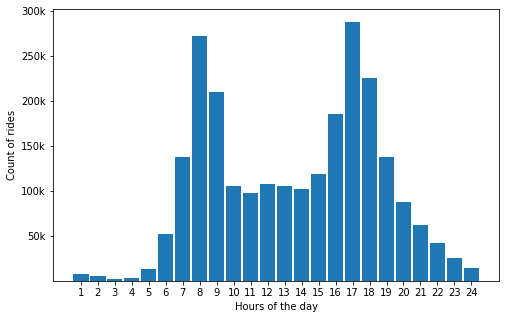

```python
#Plot the distribution of the count of rides along the hours of the day
plt.figure(figsize = [8, 5])

bin_edges = np.arange(0.5, 24.5+1, 1)

ticks = np.arange(1, 24+1, 1)
labels = ['{}'.format(val) for val in ticks]

plt.hist(data = df_allyear, x = 'time', bins = bin_edges,rwidth=0.9)

plt.xticks(ticks,labels)
plt.yticks([50000, 1e5, 1.5e5, 2e5, 2.5e5, 3e5], ['50k', '100k', '150k', '200k', '250k', '300k'])

plt.xlabel('Hours of the day')
plt.ylabel('Count of rides');
```

> As expected, the daily distribution of trips is bimodal, with one peak between 7-8 a.m., and a second peak between 4-7 p.m. This means that the bikes are mostly used during the busy hours, when people are going from home to work and back.

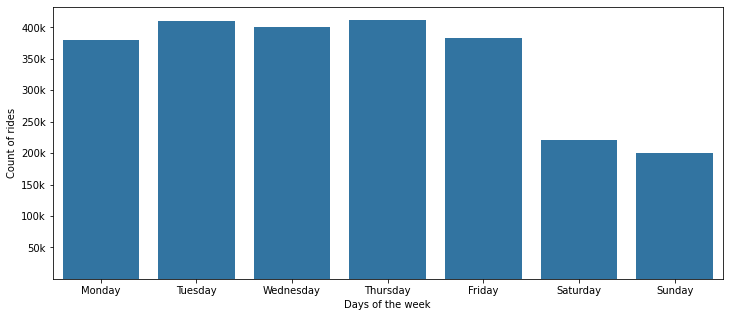

```python
#Plot the count of trips for each day of the week

plt.figure(figsize = [12, 5])

sb.countplot(data=df_allyear,x='day',color=base_color,
             order=order_dayofweek)
plt.xlabel('Days of the week')
plt.ylabel('Count of rides')

plt.yticks([50000, 1e5, 1.5e5, 2e5, 2.5e5, 3e5,3.5e5,4e5], ['50k', '100k', '150k', '200k', '250k', '300k','350k','400k'])

plt.show();
```

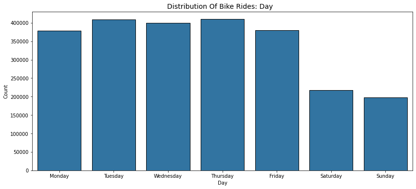

```python
#Alternative plot using function
Countplot(df_allyear, 'day',order=order_dayofweek);
```

> This plot shows the distribution of rides between the different days of the week. We can state that there are no major differences between the weekdays. On the other hand, there is an accentuated drop in rides comparing weekdays and wekends. The day of the week with less recorded rides is Sunday.

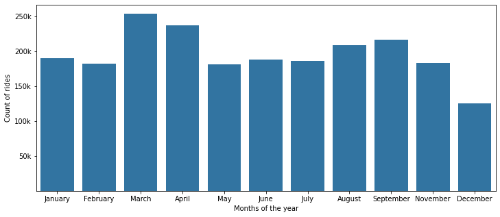

```python
#Plot the count of trips for each month of the year 2019
plt.figure(figsize = [12, 5])

sb.countplot(data=df_allyear,x='month',color=base_color,
             order=order_month)
plt.xlabel('Months of the year')
plt.ylabel('Count of rides')

plt.yticks([50000, 1e5, 1.5e5, 2e5, 2.5e5], ['50k', '100k', '150k', '200k', '250k'])

plt.show();
```

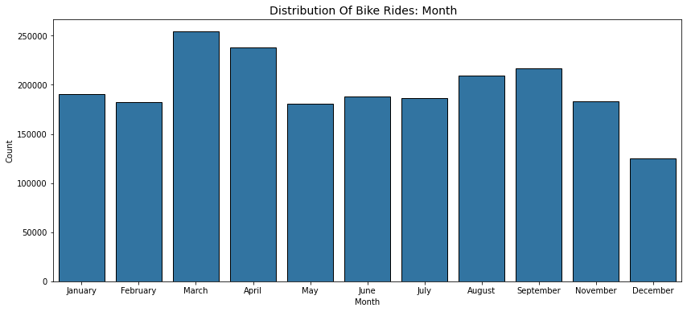

```python
#Alternative plot using function
Countplot(df_allyear, 'month',order=order_month);
```

Understand the distribution of the duration of trips variable.

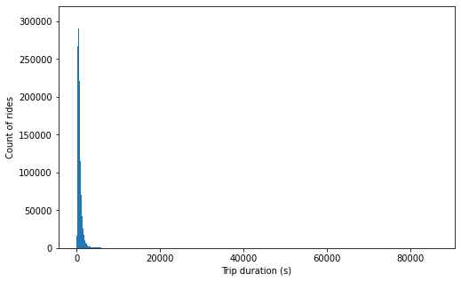

```python
#Plot the distribution of the rides duration
plt.figure(figsize = [8, 5])

bin_edges=np.arange(0, df_allyear['duration_sec'].max()+100, 100)

sb.distplot(df_allyear['duration_sec'], bins = bin_edges, kde = False,
            hist_kws = {'alpha' : 1});

plt.xlabel('Trip duration (s)')
plt.ylabel('Count of rides')

plt.show();
```

> The distribution of the duration of trips is extremely skewed to the right. Next, it will be applied a logarithmic scale.

```python
np.log10(df_allyear['duration_sec'].describe())
```

```
count    6.381523
mean     2.905697
std      3.281197
min      1.778151
25%      2.553883
50%      2.755112
75%      2.945961
max      4.935658
Name: duration_sec, dtype: float64
```

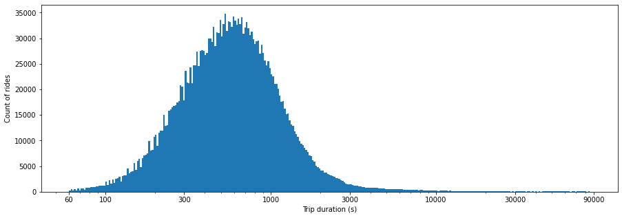

```python
#Plot the distribution of the rides duration
plt.figure(figsize = [15, 5])

# Get the ticks for bins between [0 - maximum duration_sec]
bin_edges = 10 ** np.arange(1.77, np.log10(df_allyear['duration_sec'].max())+0.01, 0.01)

# Generate the x-ticks you want to apply
ticks = [60,100, 300, 1000,3000,10000,30000,90000]
# Convert ticks into string values, to be displaye dlong the x-axis
labels = ['{}'.format(v) for v in ticks]

# Plot the histogram
sb.distplot(df_allyear['duration_sec'], bins = bin_edges, kde = False,
            hist_kws = {'alpha' : 1});

# The argument in the xscale() represents the axis scale type to apply.
plt.xscale('log')

# Apply x-ticks
plt.xticks(ticks, labels)

plt.xlabel('Trip duration (s)')
plt.ylabel('Count of rides');

plt.show();
```

> When we apply a logarithmic scale transformation to the x axis, the distribution becomes normal.

```python
nr_outliers=df_allyear.loc[df_allyear['duration_sec']>6000].duration_sec.count()
perc_outliers=nr_outliers/df_allyear.duration_sec.count()*100
perc_outliers
```

```
0.5786664417912656
```

> I will consider values above 6k seconds (= more than 1h30) as outliers because they are less than 1% of the data.

```python
#Remove the outliers from the dataframe
df_allyear=df_allyear.loc[df_allyear['duration_sec']<6000]
```

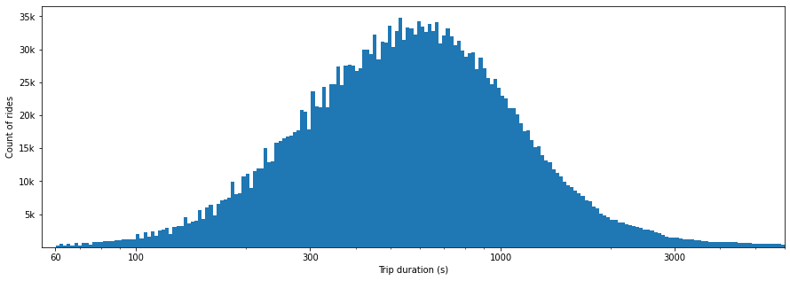

```python
#Plot the distribution of the rides duration
plt.figure(figsize = [15, 5])

# Get the ticks for bins between [0 - maximum duration_sec]
bin_edges = 10 ** np.arange(1.77, np.log10(df_allyear['duration_sec'].max())+0.01, 0.01)

# Generate the x-ticks you want to apply
ticks = [60,100, 300, 1000,3000,10000,30000,90000]
# Convert ticks into string values, to be displaye dlong the x-axis
labels = ['{}'.format(v) for v in ticks]

# Plot the histogram
sb.distplot(df_allyear['duration_sec'], bins = bin_edges, kde = False,
            hist_kws = {'alpha' : 1});

# The argument in the xscale() represents the axis scale type to apply.
plt.xscale('log')

# Apply x-ticks
plt.xticks(ticks, labels)
plt.xlim(55,6000)
plt.yticks([5000, 1e4, 1.5e4, 2e4, 2.5e4, 3e4,3.5e4], ['5k', '10k', '15k', '20k', '25k', '30k','35k'])
plt.xlabel('Trip duration (s)')
plt.ylabel('Count of rides');

plt.show()
```

> After analysing the dataset that includes data about trips for all months of the year 2019, it was possible to get the following insights:

> ```
> - The bike-sharing system covering the greater San Francisco Bay area is more used during weekdays than weekends;
> - Along the year, the trips recorded followed a bimodal distribution, being March the month with the highest count of trips. Although there is no explanation for March as the highest peak of rides, the second peak being during fall suggests that people use more bike-sharing system in better weather condition.
> - Regarding the distribution of the duration of the trips, it follows a normal distribution when we apply a logarithmic transformation.
> ```

Understand the distribution of the member_age variable.

Since we do not have the `member_age` variable available in all the months' datasets, in order to explore it, it will be used another dataframe with data of February 2019.

But first, the outliers discovered in the previous insights will be also ignored for this dataset.

```python
#Remove the outliers from the dataframe
df=df.loc[df['duration_sec']<6000]
```

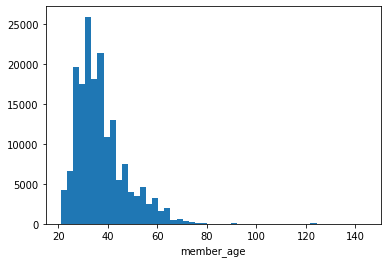

```python
#Plot the age of the users distribution
sb.distplot(df['member_age'], bins = 50, kde = False,
            hist_kws = {'alpha' : 1});
```

> It is possible to notice some outliers. For example, values for ages above 120 years seem incorrect and doubtful. Also, as this is about a bike sharing system, which only works with technology and evolves physical effort, I would not consider people above 80 years-old to use it.

```python
#Explore members aged above 70 years
high_outliers = ((df['member_age'] > 70))
print(high_outliers.sum())
df_ageout=df.loc[high_outliers,:]
```

```
1027
```

> There are more than 1k users with ages above 70 years, which seems an high value.

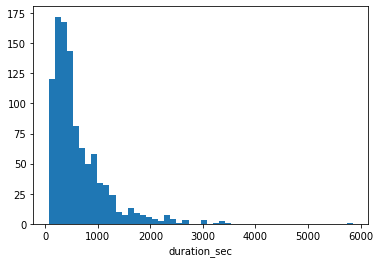

```python
sb.distplot(df_ageout['duration_sec'], bins = 50, kde = False,
            hist_kws = {'alpha' : 1});
```

> When we look at the distribution of the duration of trips for these users with more than 70 years of age, we can see that some reach to trips with duration of over 30 minutes (1800 s), but they are not considerable. In this case, they will be removed. I will not remove all the users with age above 70 years old because... they might be healthy indeed!!

```python
df_ageout.loc[df_ageout['duration_sec']>1800].duration_sec.count()
```

```
42
```

```python
df=df.loc[~((df['member_age'] > 70) & (df['duration_sec'] > 1800) |(df['member_age'] > 80))]
```

```python
df.loc[df['member_age'] > 70].duration_sec.count()
```

```
779
```

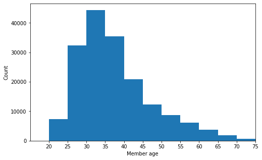

```python
#Plot the distribution of the age without outliers
plt.figure(figsize = [8, 5])

# Generate the x-ticks you want to apply
ticks = np.arange(20, df['member_age'].max()+5, 5)
# Convert ticks into string values, to be displaye dlong the x-axis
labels = ['{}'.format(v) for v in ticks]

bin_edges=np.arange(0, df['member_age'].max()+5, 5)

sb.distplot(df['member_age'], bins = bin_edges, kde = False,
            hist_kws = {'alpha' : 1})

plt.xlabel('Member age')
plt.ylabel('Count')
plt.xticks(ticks, labels)
plt.xlim(15,75)

plt.show()
```

> The majority of the users are between 25 and 40 years-old. The distribution of ages is right-skewed, which is expected in this case: the young people adhere more to the bike-sharing system.

### Discuss the distribution(s) of your variable(s) of interest. Were there any unusual points? Did you need to perform any transformations?

> In this first part, 5 different distributions were evaluated:

> ```
> - Distribution of rides along the hours of the day, considering data for 2019 year
> - Distribution of rides during the week/weekend days, considering data for 2019 year
> - Distribution of rides along the months of the year, considering data for 2019 year
> - Distribution of the duration of the rides, considering data for 2019 year
> - Distribution of the member ages, considering data for the month of February 2019.
> ```

> Only 1 logarithmic transformation was performed, for the distribution of the duration of the rides.

### Of the features you investigated, were there any unusual distributions? Did you perform any operations on the data to tidy, adjust, or change the form of the data? If so, why did you do this?

> With the investigation of these distributions the outliers were defined and removed from the dataframes in study.

## Bivariate Exploration

In this section, the focus was to explore relationships between all types of variables:

- Quantitative vs. Quantitative
- Quantitative vs. Qualitative
- Qualitative vs. Qualitative

To do that, other variables not presented in the first part were used.

Quantitative vs. Quantitative

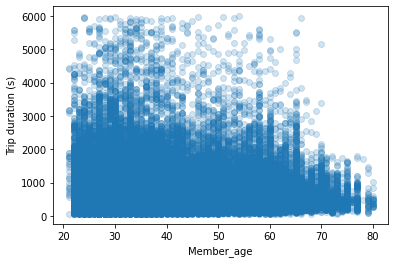

```python
#Plot age vs. duration_sec
sb.regplot(data=df, x='member_age', y='duration_sec', color=base_color,fit_reg=False,
           truncate=False, y_jitter=0.5, scatter_kws={'alpha':1/5});
plt.xlabel('Member_age')
plt.ylabel('Trip duration (s)');
```

> This plot suggests that the relationship between the age of the members and the duration of trips does not follow a linear one. It is possible to notice that point with higher trip durations are less frequent when the age increases.

Quantitative vs. Qualitative

```python
df_weekday=df_allyear.loc[df_allyear['day_type']=='Weekday']
df_weekend=df_allyear.loc[df_allyear['day_type']=='Weekend']
```

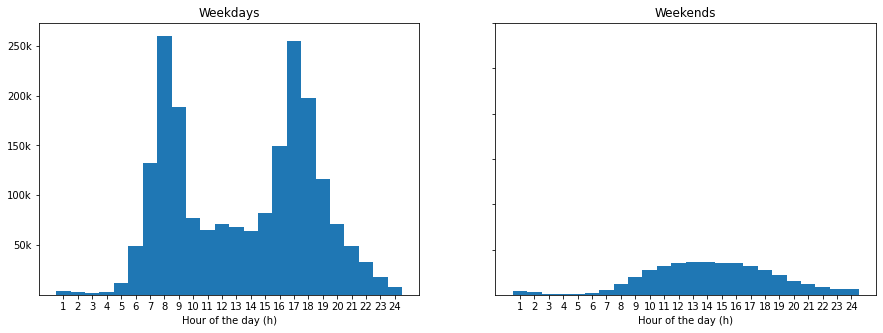

```python
#Plot the distribution of the count of rides along the hours of the weekdays and weekends, comparison
bin_edges = np.arange(0.5, 24.5+1, 1)
ticks = np.arange(1, 24+1, 1)
labels = ['{}'.format(val) for val in ticks]

fig, ax = plt.subplots(ncols=2, figsize = [15,5], sharex=True, sharey=True)

sb.distplot(df_weekday['time'], bins = bin_edges, kde = False,  hist_kws = {'alpha' : 1},ax = ax[0])
ax[0].set_xlabel('Hour of the day (h)')
ax[0].set_title('Weekdays')

sb.distplot(df_weekend['time'], bins = bin_edges, kde = False,
            hist_kws = {'alpha' : 1},ax = ax[1])
ax[1].set_xlabel('Hour of the day (h)')
ax[1].set_title('Weekends')

plt.xticks(ticks,labels)
plt.yticks([50000, 1e5, 1.5e5, 2e5, 2.5e5, 3e5], ['50k', '100k', '150k', '200k', '250k', '300k'])

plt.show();
```